# Project: vectors and functions

R Workshop

#### Recall:

- The first element of the vector corresponds to the average temperature in January of 1881. The second element is February 1881, etc. The last element is December 2012.
- Each element in the vector is the scaled deviation (by 100) from a baseline mean global temperature in Celsius. The baseline mean global temperature is the global temperature from 1951-1980, which is 14.0o C (57.2o Fahrenheit).
- For data details, read the bottom of the Nasa page: http://data.giss.nasa.gov/gistemp/tabledata_v3/GLB.Ts+dSST.txt

#### Some requests

- If there are some tasks that you can imagine needing to code up again, *write a function for it*.
- Your final html document should read like an informative analysis of this temperature data set meant to be consumed by a non-programmer. That is,
  - Supress R code (though an exception may be easy-to-read output).
  - The narrative should be as in a natural analysis; not as a collection of enumerated answers to exercises.
  - Use sensible Markdown sytax for organization.
  - Fiddle with “knitr chunk options” to get the figures you’re going for.
- Your source, however, should be crystal clear to another programmer.
  - Code with style.
  - Label your chunks.

Please complete the following exercises using R vectors:

1. Convert the data from scaled deviation in Celsius to absolute temperature in Fahrenheit. What is the mean temperature in Fahrenheit over the entire data set? Confirm that your result is reasonable. Use your new Fahrenheit vector for the rest of the exercises.

```
## [1] 57.1721
```

-Global Temperatures -  
This project studies the average global temperatures starting from January 1881 and ending in December 2012. The data was parsed and analyzed to get some insights on average global temperatures. The mean temperature of the entire data set was found to be 57.1721023

1. Find the mean global temperature of each the summer months: June, July, and August. Also please find the lowest and highest global average temperatures for each month. This is easiest if you create new vectors that have all June temperatures, all July temperatures, and so on. When did the lowest and highest occur for each month? Are the highest temperatures generally more recent than the lowest temperatures?

```
##      Jun      Jul      Aug
## 57.12732 57.17845 57.17245
```

```
##    Jan    Feb    Mar    Apr    May    Jun    Jul    Aug    Sep    Oct
## 58.874 58.748 58.802 58.658 58.460 58.514 58.442 58.442 58.460 58.550
##    Nov    Dec
## 58.550 58.532
```

```
##    Jan    Feb    Mar    Apr    May    Jun    Jul    Aug    Sep    Oct
## 55.688 56.120 56.066 56.192 56.156 56.282 56.354 56.138 56.210 56.066
##    Nov    Dec
## 56.210 55.868
```

```
##  Jan  Feb  Mar  Apr  May  Jun  Jul  Aug  Sep  Oct  Nov  Dec
## 2008 1999 2003 2011 2011 1999 2012 2012 2006 2006 2011 2007
```

```
##  Jan  Feb  Mar  Apr  May  Jun  Jul  Aug  Sep  Oct  Nov  Dec
## 1894 1906 1912 1910 1918 1910 1913 1913 1913 1913 1911 1917
```

The table below shows the lowest temperatures in Farenheit per month and their corresponding year. 55.69, 1894, 56.12, 1906, 56.07, 1912, 56.19, 1910, 56.16, 1918, 56.28, 1910, 56.35, 1913, 56.14, 1913, 56.21, 1913, 56.07, 1913, 56.21, 1911, 55.87, 1917 — end —-

1. For the rest of the project, it will be helpful to define two functions. Define one function that takes the month and year as input and outputs the index in the vector for that given month and year. Define another function that takes the index in the vector as the input and outputs the month and year.

```r
month_year_to_index <- function(month = 1, year = 1881) {
  y <- year - 1881
  return(y*12 + month)
}

index_to_month_year <- function(ind = 1) {
  month <- (ind %% 12)
  y <- floor(ind / 12)
  return(c(month, y+1881))
}
```

Some examples to demonstrate the functions:

```r
month_year_to_index(1, 1881)
```

```
## [1] 1
```

```r
month_year_to_index(2, 1881)
```

```
## [1] 2
```

```r
month_year_to_index(1, 1882)
```

```
## [1] 13
```

```r
index_to_month_year(1)
```

```
## [1]    1 1881
```

```r
index_to_month_year(2)
```

```
## [1]    2 1881
```

```r
index_to_month_year(13)
```

```
## [1]    1 1882
```

1. Create plots of the monthly average temperature over time for each month: one plot for all January average temperatures, one plot for all February average temperatures, etc. To make a plot with a single vector, use the `plot()` function. The plots should have *Years* on the horizontal axis, and *Temperature* on the vertical axis. Does there seem to be a warming trend? The previously defined functions will be helpful here. Feel free to fiddle with the optional arguments to `plot()` (more are found with `?par`).

— Added

The plots below show the montHly average temperature from 1881 to 2012 time period. The plots have years in the horizontal axis and temperatures in the vertical axis. As we can see, the plots show an increasing trend. —– End

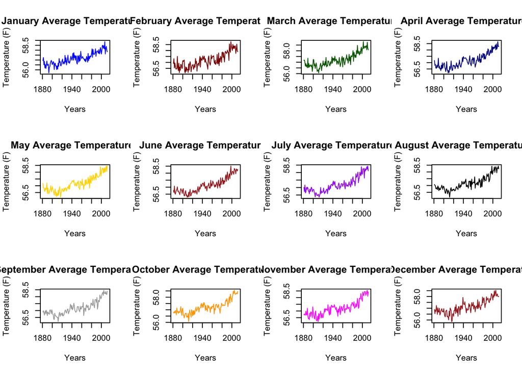

1. Create a plot that shows the average annual temperature over all years. (That is, create one plot where each data point corresponds to the average temperature for a year.) In what years did the highest and lowest average temperatures occur?

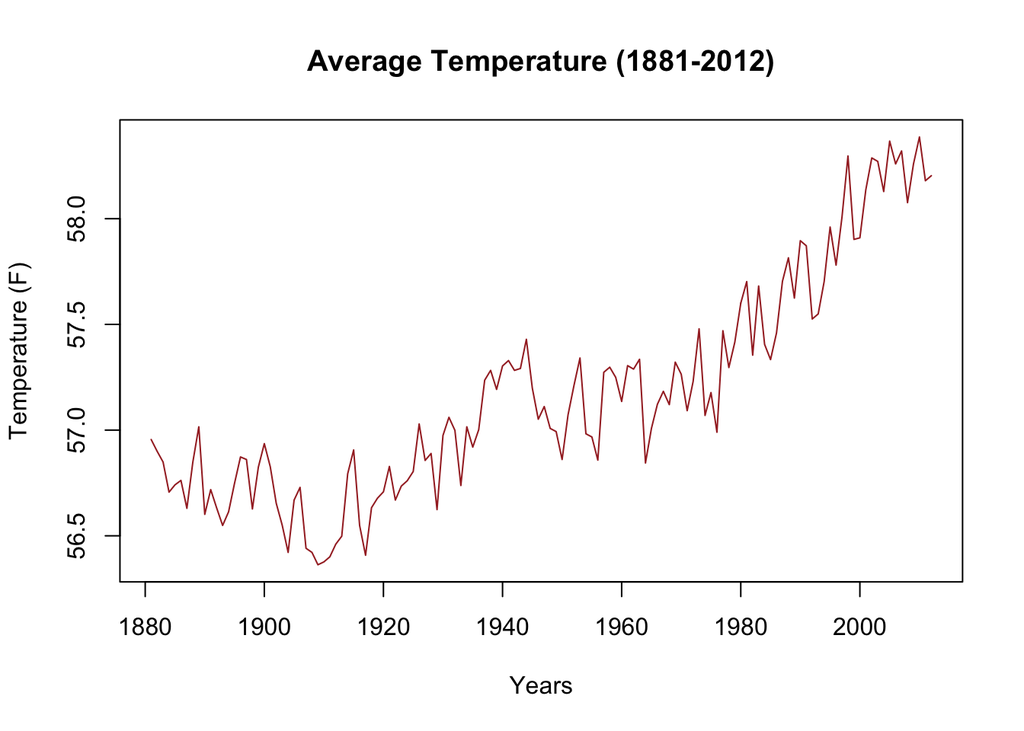

1. Create a plot showing the monthly average temperature starting at January 2000 (one plot showing all data points from January 2000 through December 2012). Do you see any pattern to the data? Are temperatures rising? The previously defined functions will be helpful here.

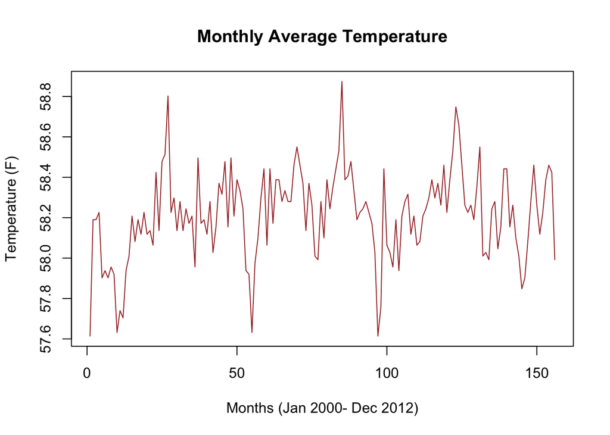

—- Added The graph above shows the average temperature from January 2000 to December 2012. From this plot, there is no clear pattern but there seems to be a trend of increasing temperatures. —– End

1. Create a plot of the monthly average temperatures starting at January 1990 and ending on December 1999. Do you see any pattern to the data? Are temperatures rising? Which months had the highest and lowest temperatures?

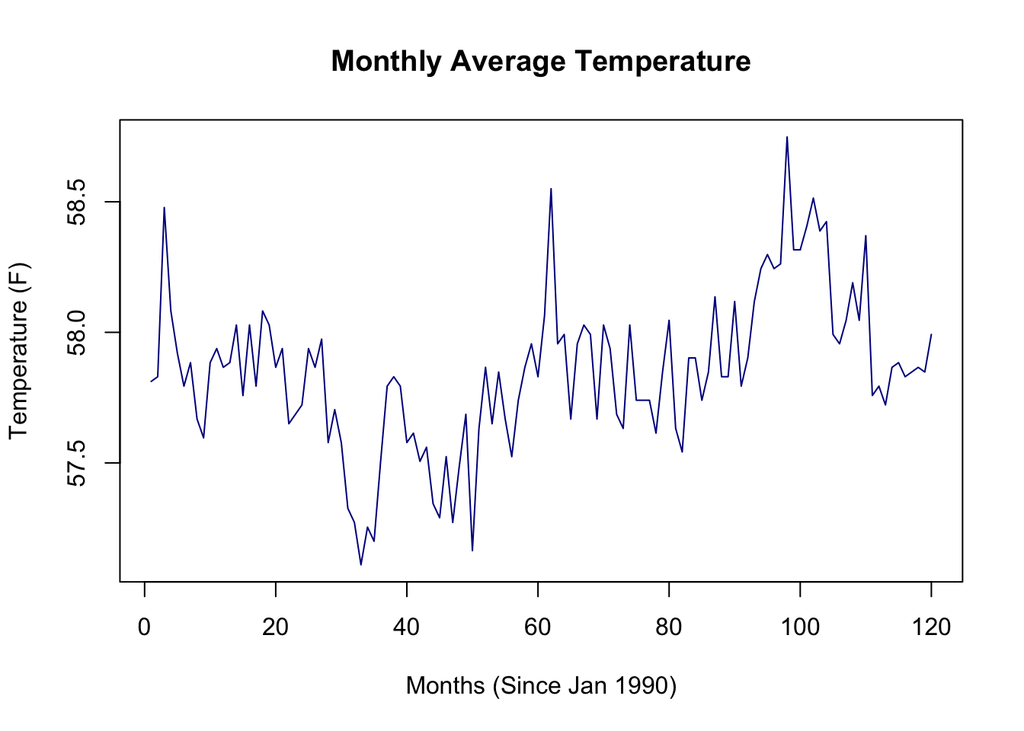

1. Plot the monthly average temperature of every month in the 1890s. What is the mean temperature of this decade? How does this decade compare to the 1990s?

[figure not shown]

```r
temp_m_1880s<- temp_matrix[, 10:19]
plot(1:120, as.vector(temp_m_1880s), ylab = "Temperature (F)", xlab ="Months in the 1880's", pch = 19, col = "brown", cex = 0.3, main = " 1890's Monthly Average Temperature", type = "l")
```

1. Create plots of the monthly averages of the first 44 years, the second 44 years, and the last 43 years. Do you see any warming trends in any of these plots? What is the average temperature of each of these time periods? Remember to use the previously defined functions!

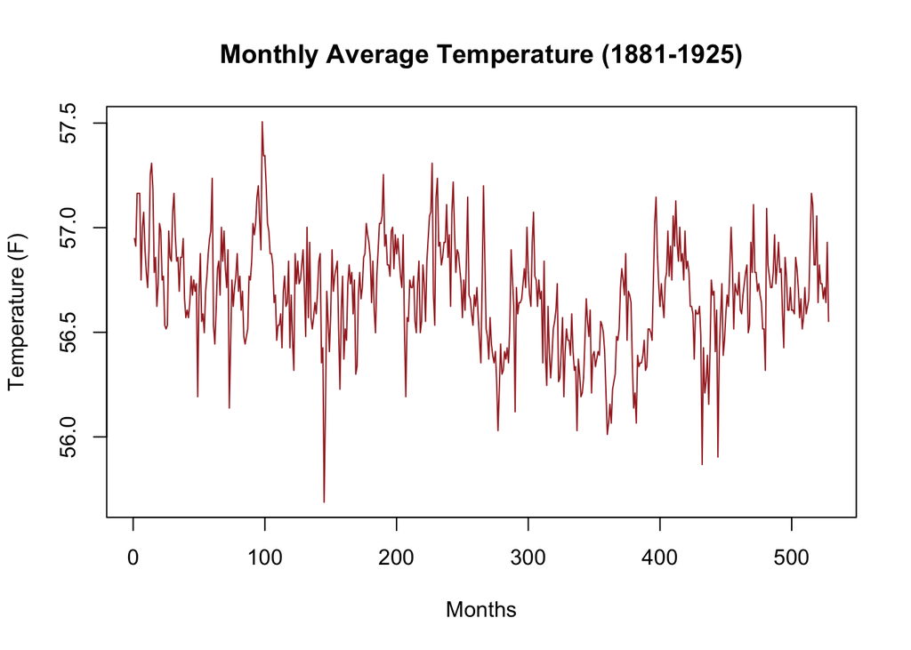

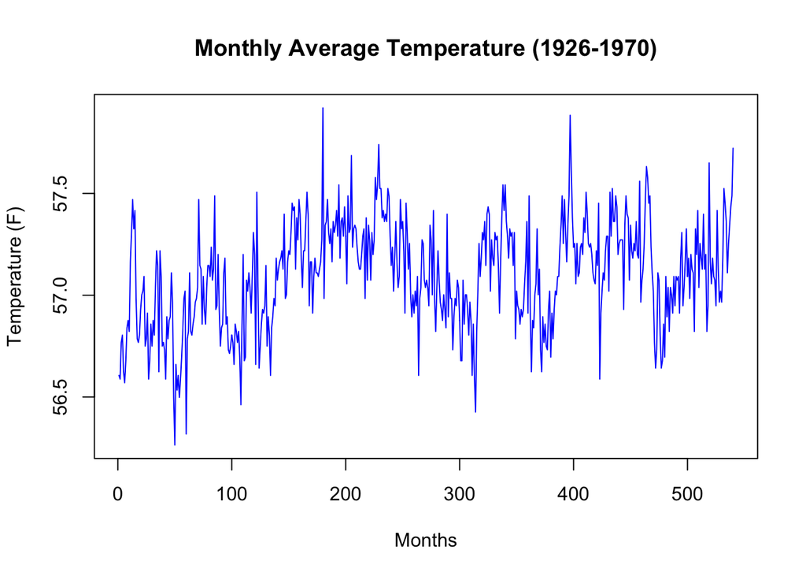

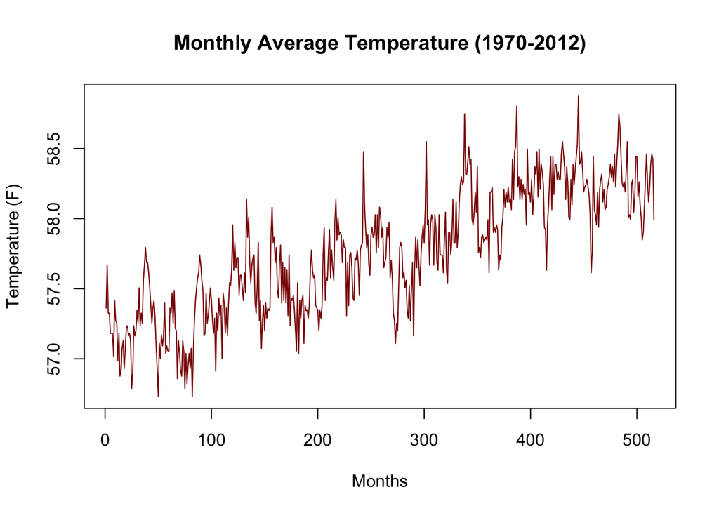

Adapted from material developed by Olaf Hall-Holt and Paul Roback for CS 125 at St. Olaf College.